# SEC_GT: Secundaria - Geometría y Trigonometría

**[Referencia: SEC_GT_IdentificarSuficienciaCongruencia]**

Leer la siguiente afirmación. La figura que acompaña es una figura de análisis, es decir, es una figura alusiva.

*Se tienen los triángulos ABC y A'B'C'. Si AB mide igual que A'B', CA mide igual que C'A' y el ángulo ACB mide igual que el A'C'B', entonces, por el criterio Lado-Ángulo-Lado (LAL) los triángulos ABC y A'B'C' son congruentes.*

¿Es correcto lo que se afirma?

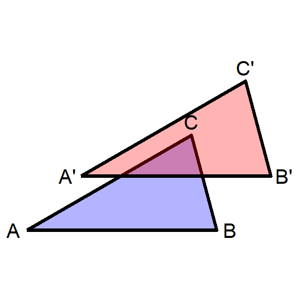

CorrectoIncorrecto

La afirmación es incorrecta.

**[Referencia: SEC_GT_IdentificarSuficienciaCongruencia]**

*Se tienen los triángulos ABC y A'B'C'. Si los ángulos de los vértices C y B son de igual medida que los de los vértices C' y B', respectivamente, y el lado CB es de igual medida que el C'B', entonces, por el criterio Ángulo-Lado-Ángulo (ALA) los triángulos ABC y A'B'C' son congruentes.*

¿Es correcto lo que se afirma?

CorrectoIncorrecto

La afirmación es correcta.

**[Referencia: SEC_GT_IdentificarSuficienciaCongruencia]**

Leer la siguiente afirmación. La figura que acompaña es una figura de análisis, es decir, es una figura alusiva.

*Se tienen los triángulos ABC y A'B'C'. Si AB mide igual que A'B', CA mide igual que C'A' y el ángulo del vértice A mide igual que el del vértice A', entonces, por el criterio Lado-Ángulo-Lado (LAL) los triángulos ABC y A'B'C' son congruentes.*

¿Es correcto lo que se afirma?

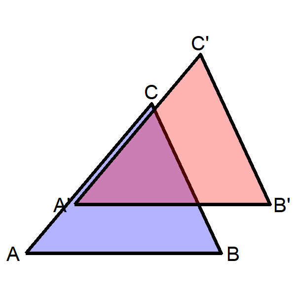

CorrectoIncorrecto

La afirmación es correcta.

**[Referencia: SEC_GT_IdentificarSuficienciaCongruencia]**

*Se tienen los triángulos ABC y A'B'C'. Si AB mide igual que A'B', CA mide igual que C'A' y el ángulo del vértice A mide igual que el del vértice A', entonces, por el criterio Lado-Ángulo-Lado (LAL) los triángulos ABC y A'B'C' son congruentes.*

¿Es correcto lo que se afirma?

CorrectoIncorrecto

La afirmación es correcta.

**[Referencia: SEC_GT_IdentificarSuficienciaCongruencia]**

Leer la siguiente afirmación. La figura que acompaña es una figura de análisis, es decir, es una figura alusiva.

*Se tienen los triángulos ABC y A'B'C'. Si AB mide igual que A'B', CA mide igual que C'A' y el ángulo del vértice A mide igual que el del vértice A', entonces, por el criterio Lado-Ángulo-Lado (LAL) los triángulos ABC y A'B'C' son congruentes.*

¿Es correcto lo que se afirma?

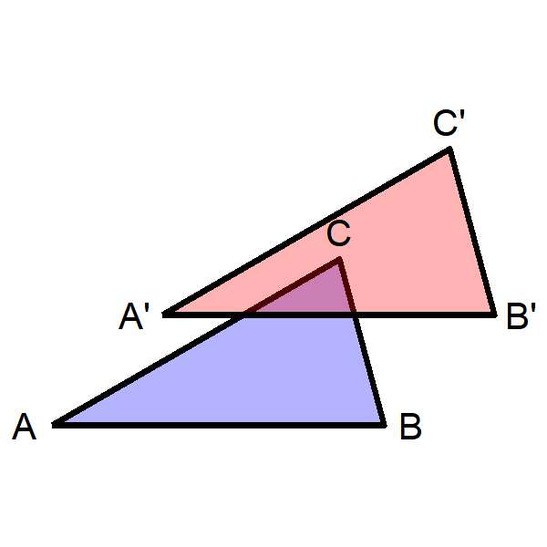

CorrectoIncorrecto

La afirmación es correcta.

**[Referencia: SEC_GT_IdentificarSuficienciaCongruencia]**

Leer la siguiente afirmación. La figura que acompaña es una figura de análisis, es decir, es una figura alusiva.

*Se tienen los triángulos ABC y A'B'C'. Si AB mide igual que A'B', CA mide igual que C'A' y el ángulo ACB mide igual que el A'C'B', entonces, por el criterio Lado-Ángulo-Lado (LAL) los triángulos ABC y A'B'C' son congruentes.*

¿Es correcto lo que se afirma?

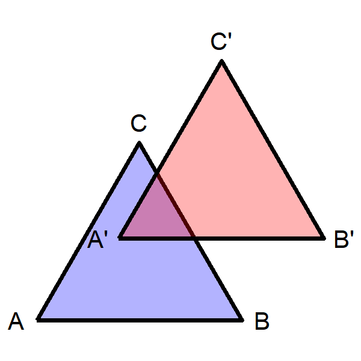

CorrectoIncorrecto

La afirmación es incorrecta.

**[Referencia: SEC_GT_IdentificarSuficienciaCongruencia]**

*Se tienen los triángulos ABC y A'B'C'. Si AB mide igual que A'B', CA mide igual que C'A' y el ángulo del vértice A mide igual que el del vértice A', entonces, por el criterio Lado-Ángulo-Lado (LAL) los triángulos ABC y A'B'C' son congruentes.*

¿Es correcto lo que se afirma?

CorrectoIncorrecto

La afirmación es correcta.

**[Referencia: SEC_GT_IdentificarSuficienciaCongruencia]**

Leer la siguiente afirmación. La figura que acompaña es una figura de análisis, es decir, es una figura alusiva.

*Se tienen los triángulos ABC y A'B'C'. Si los ángulos de los vértices C y B son de igual medida que los de los vértices C' y B', respectivamente, y el lado CB es de igual medida que el C'B', entonces, por el criterio Ángulo-Lado-Ángulo (ALA) los triángulos ABC y A'B'C' son congruentes.*

¿Es correcto lo que se afirma?

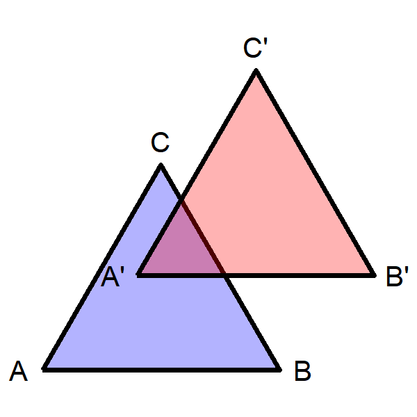

CorrectoIncorrecto

La afirmación es correcta.

**[Referencia: SEC_GT_IdentificarSuficienciaCongruencia]**

Leer la siguiente afirmación. La figura que acompaña es una figura de análisis, es decir, es una figura alusiva.

*Se tienen los triángulos ABC y A'B'C'. Si los ángulos de los vértices C y B son de igual medida que los de los vértices C' y B', respectivamente, y el lado CB es de igual medida que el C'B', entonces, por el criterio Ángulo-Lado-Ángulo (ALA) los triángulos ABC y A'B'C' son congruentes.*

¿Es correcto lo que se afirma?

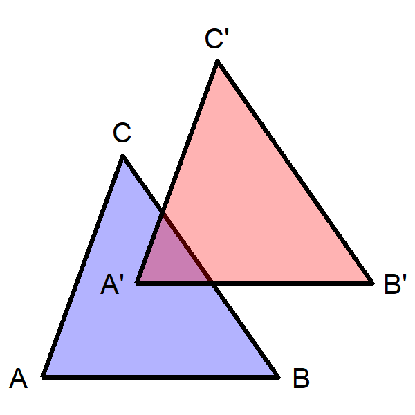

CorrectoIncorrecto

La afirmación es correcta.

**[Referencia: SEC_GT_IdentificarSuficienciaCongruencia]**

*Se tienen los triángulos ABC y A'B'C'. Si los ángulos de los vértices C y B son de igual medida que los de los vértices C' y B', y el lado AB es de igual medida que el A'B', entonces, por el criterio Ángulo-Lado-Ángulo (ALA) los triángulos ABC y A'B'C' son congruentes.*

¿Es correcto lo que se afirma?

CorrectoIncorrecto

La afirmación es incorrecta.

**[Referencia: SEC_GT_IdentificarSuficienciaCongruencia]**

*Se tienen los triángulos ABC y A'B'C'. Si AB mide igual que A'B', CA mide igual que C'A' y el ángulo ACB mide igual que el A'C'B', entonces, por el criterio Lado-Ángulo-Lado (LAL) los triángulos ABC y A'B'C' son congruentes.*

¿Es correcto lo que se afirma?

CorrectoIncorrecto

La afirmación es incorrecta.

**[Referencia: SEC_GT_IdentificarSuficienciaCongruencia]**

Leer la siguiente afirmación. La figura que acompaña es una figura de análisis, es decir, es una figura alusiva.

*Se tienen los triángulos ABC y A'B'C'. Si AB mide igual que A'B', CA mide igual que C'A' y el ángulo del vértice A mide igual que el del vértice A', entonces, por el criterio Lado-Ángulo-Lado (LAL) los triángulos ABC y A'B'C' son congruentes.*

¿Es correcto lo que se afirma?

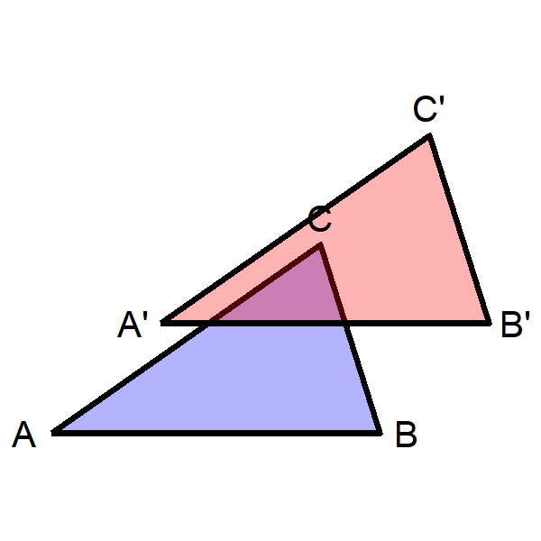

CorrectoIncorrecto

La afirmación es correcta.

**[Referencia: SEC_GT_IdentificarSuficienciaCongruencia]**

*Se tienen los triángulos ABC y A'B'C'. Si AB mide igual que A'B', CA mide igual que C'A' y el ángulo ACB mide igual que el A'C'B', entonces, por el criterio Lado-Ángulo-Lado (LAL) los triángulos ABC y A'B'C' son congruentes.*

¿Es correcto lo que se afirma?

CorrectoIncorrecto

La afirmación es incorrecta.

**[Referencia: SEC_GT_IdentificarSuficienciaCongruencia]**

*Se tienen los triángulos ABC y A'B'C'. Si los ángulos de los vértices C y B son de igual medida que los de los vértices C' y B', respectivamente, y el lado CB es de igual medida que el C'B', entonces, por el criterio Ángulo-Lado-Ángulo (ALA) los triángulos ABC y A'B'C' son congruentes.*

¿Es correcto lo que se afirma?

CorrectoIncorrecto

La afirmación es correcta.

**[Referencia: SEC_GT_IdentificarSuficienciaCongruencia]**

*Se tienen los triángulos ABC y A'B'C'. Si AB mide igual que A'B', CA mide igual que C'A' y el ángulo ACB mide igual que el A'C'B', entonces, por el criterio Lado-Ángulo-Lado (LAL) los triángulos ABC y A'B'C' son congruentes.*

¿Es correcto lo que se afirma?

CorrectoIncorrecto

La afirmación es incorrecta.

**[Referencia: SEC_GT_IdentificarSuficienciaCongruencia]**

Leer la siguiente afirmación. La figura que acompaña es una figura de análisis, es decir, es una figura alusiva.

*Se tienen los triángulos ABC y A'B'C'. Si AB mide igual que A'B', CA mide igual que C'A' y el ángulo del vértice A mide igual que el del vértice A', entonces, por el criterio Lado-Ángulo-Lado (LAL) los triángulos ABC y A'B'C' son congruentes.*

¿Es correcto lo que se afirma?

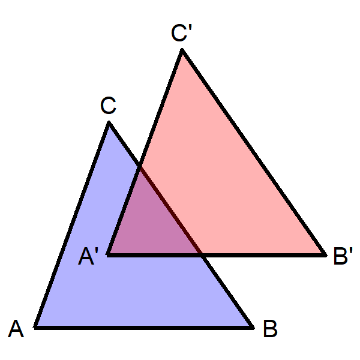

CorrectoIncorrecto

La afirmación es correcta.

**[Referencia: SEC_GT_IdentificarSuficienciaCongruencia]**

*Se tienen los triángulos ABC y A'B'C'. Si los ángulos de los vértices C y B son de igual medida que los de los vértices C' y B', y el lado AB es de igual medida que el A'B', entonces, por el criterio Ángulo-Lado-Ángulo (ALA) los triángulos ABC y A'B'C' son congruentes.*

¿Es correcto lo que se afirma?

CorrectoIncorrecto

La afirmación es incorrecta.

**[Referencia: SEC_GT_IdentificarSuficienciaCongruencia]**

*Se tienen los triángulos ABC y A'B'C'. Si AB mide igual que A'B', CA mide igual que C'A' y el ángulo del vértice A mide igual que el del vértice A', entonces, por el criterio Lado-Ángulo-Lado (LAL) los triángulos ABC y A'B'C' son congruentes.*

¿Es correcto lo que se afirma?

CorrectoIncorrecto

La afirmación es correcta.

**[Referencia: SEC_GT_IdentificarSuficienciaCongruencia]**

*Se tienen los triángulos ABC y A'B'C'. Si los ángulos de los vértices C y B son de igual medida que los de los vértices C' y B', respectivamente, y el lado CB es de igual medida que el C'B', entonces, por el criterio Ángulo-Lado-Ángulo (ALA) los triángulos ABC y A'B'C' son congruentes.*

¿Es correcto lo que se afirma?

CorrectoIncorrecto

La afirmación es correcta.

**[Referencia: SEC_GT_IdentificarSuficienciaCongruencia]**

*Se tienen los triángulos ABC y A'B'C'. Si los ángulos de los vértices C y B son de igual medida que los de los vértices C' y B', y el lado AB es de igual medida que el A'B', entonces, por el criterio Ángulo-Lado-Ángulo (ALA) los triángulos ABC y A'B'C' son congruentes.*

¿Es correcto lo que se afirma?

CorrectoIncorrecto

La afirmación es incorrecta.

**[Referencia: SEC_GT_IdentificarSuficienciaCongruencia]**

*Se tienen los triángulos ABC y A'B'C'. Si AB mide igual que A'B', CA mide igual que C'A' y el ángulo del vértice A mide igual que el del vértice A', entonces, por el criterio Lado-Ángulo-Lado (LAL) los triángulos ABC y A'B'C' son congruentes.*

¿Es correcto lo que se afirma?

CorrectoIncorrecto

La afirmación es correcta.

**[Referencia: SEC_GT_IdentificarSuficienciaCongruencia]**

*Se tienen los triángulos ABC y A'B'C'. Si los ángulos de los vértices C y B son de igual medida que los de los vértices C' y B', respectivamente, y el lado CB es de igual medida que el C'B', entonces, por el criterio Ángulo-Lado-Ángulo (ALA) los triángulos ABC y A'B'C' son congruentes.*

¿Es correcto lo que se afirma?

CorrectoIncorrecto

La afirmación es correcta.

**[Referencia: SEC_GT_IdentificarSuficienciaCongruencia]**

Leer la siguiente afirmación. La figura que acompaña es una figura de análisis, es decir, es una figura alusiva.

*Se tienen los triángulos ABC y A'B'C'. Si AB mide igual que A'B', CA mide igual que C'A' y el ángulo del vértice A mide igual que el del vértice A', entonces, por el criterio Lado-Ángulo-Lado (LAL) los triángulos ABC y A'B'C' son congruentes.*

¿Es correcto lo que se afirma?

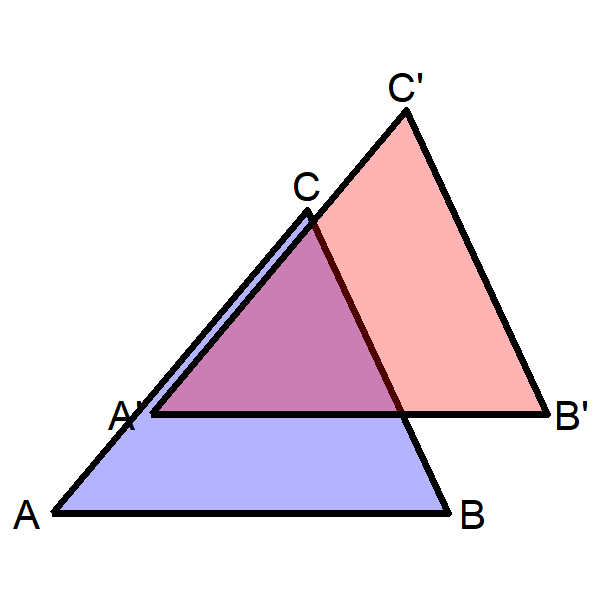

CorrectoIncorrecto

La afirmación es correcta.

**[Referencia: SEC_GT_IdentificarSuficienciaCongruencia]**

*Se tienen los triángulos ABC y A'B'C'. Si los ángulos de los vértices C y B son de igual medida que los de los vértices C' y B', respectivamente, y el lado CB es de igual medida que el C'B', entonces, por el criterio Ángulo-Lado-Ángulo (ALA) los triángulos ABC y A'B'C' son congruentes.*

¿Es correcto lo que se afirma?

CorrectoIncorrecto

La afirmación es correcta.

**[Referencia: SEC_GT_IdentificarSuficienciaCongruencia]**

Leer la siguiente afirmación. La figura que acompaña es una figura de análisis, es decir, es una figura alusiva.

*Se tienen los triángulos ABC y A'B'C'. Si los ángulos de los vértices C y B son de igual medida que los de los vértices C' y B', y el lado AB es de igual medida que el A'B', entonces, por el criterio Ángulo-Lado-Ángulo (ALA) los triángulos ABC y A'B'C' son congruentes.*

¿Es correcto lo que se afirma?

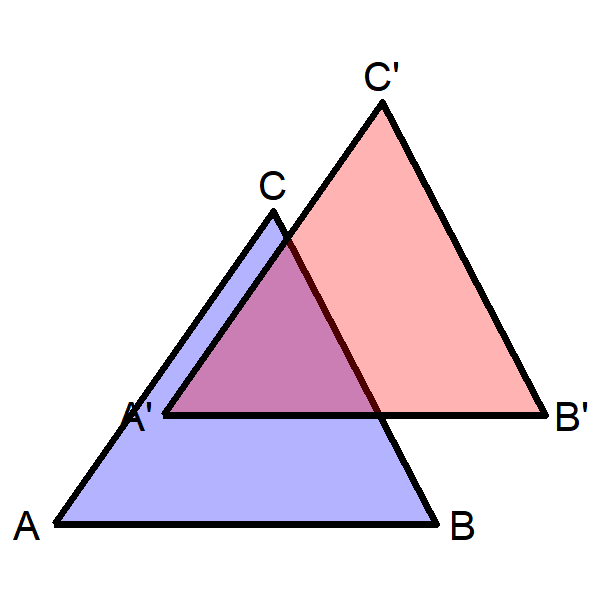

CorrectoIncorrecto

La afirmación es incorrecta.

**[Referencia: SEC_GT_IdentificarSuficienciaCongruencia]**

*Se tienen los triángulos ABC y A'B'C'. Si los ángulos de los vértices C y B son de igual medida que los de los vértices C' y B', respectivamente, y el lado CB es de igual medida que el C'B', entonces, por el criterio Ángulo-Lado-Ángulo (ALA) los triángulos ABC y A'B'C' son congruentes.*

¿Es correcto lo que se afirma?

CorrectoIncorrecto

La afirmación es correcta.

**[Referencia: SEC_GT_IdentificarSuficienciaCongruencia]**

*Se tienen los triángulos ABC y A'B'C'. Si los ángulos de los vértices C y B son de igual medida que los de los vértices C' y B', respectivamente, y el lado CB es de igual medida que el C'B', entonces, por el criterio Ángulo-Lado-Ángulo (ALA) los triángulos ABC y A'B'C' son congruentes.*

¿Es correcto lo que se afirma?

CorrectoIncorrecto

La afirmación es correcta.

**[Referencia: SEC_GT_IdentificarSuficienciaCongruencia]**

*Se tienen los triángulos ABC y A'B'C'. Si los ángulos de los vértices C y B son de igual medida que los de los vértices C' y B', respectivamente, y el lado CB es de igual medida que el C'B', entonces, por el criterio Ángulo-Lado-Ángulo (ALA) los triángulos ABC y A'B'C' son congruentes.*

¿Es correcto lo que se afirma?

CorrectoIncorrecto

La afirmación es correcta.

**[Referencia: SEC_GT_IdentificarSuficienciaCongruencia]**

Leer la siguiente afirmación. La figura que acompaña es una figura de análisis, es decir, es una figura alusiva.

*Se tienen los triángulos ABC y A'B'C'. Si los ángulos de los vértices C y B son de igual medida que los de los vértices C' y B', y el lado AB es de igual medida que el A'B', entonces, por el criterio Ángulo-Lado-Ángulo (ALA) los triángulos ABC y A'B'C' son congruentes.*

¿Es correcto lo que se afirma?

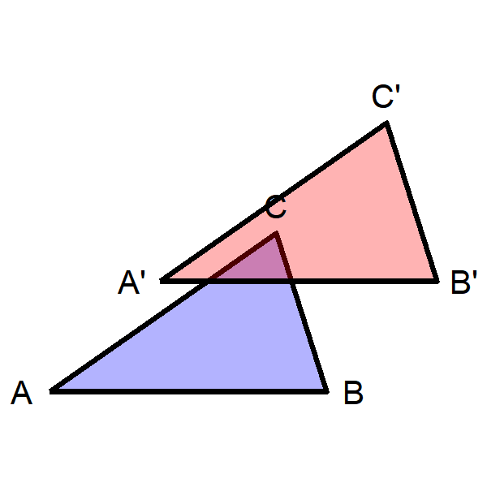

CorrectoIncorrecto

La afirmación es incorrecta.

**[Referencia: SEC_GT_IdentificarSuficienciaCongruencia]**

*Se tienen los triángulos ABC y A'B'C'. Si los ángulos de los vértices C y B son de igual medida que los de los vértices C' y B', y el lado AB es de igual medida que el A'B', entonces, por el criterio Ángulo-Lado-Ángulo (ALA) los triángulos ABC y A'B'C' son congruentes.*

¿Es correcto lo que se afirma?

CorrectoIncorrecto

La afirmación es incorrecta.

**[Referencia: SEC_GT_IdentificarSuficienciaCongruencia]**

Leer la siguiente afirmación. La figura que acompaña es una figura de análisis, es decir, es una figura alusiva.

*Se tienen los triángulos ABC y A'B'C'. Si AB mide igual que A'B', CA mide igual que C'A' y el ángulo del vértice A mide igual que el del vértice A', entonces, por el criterio Lado-Ángulo-Lado (LAL) los triángulos ABC y A'B'C' son congruentes.*

¿Es correcto lo que se afirma?

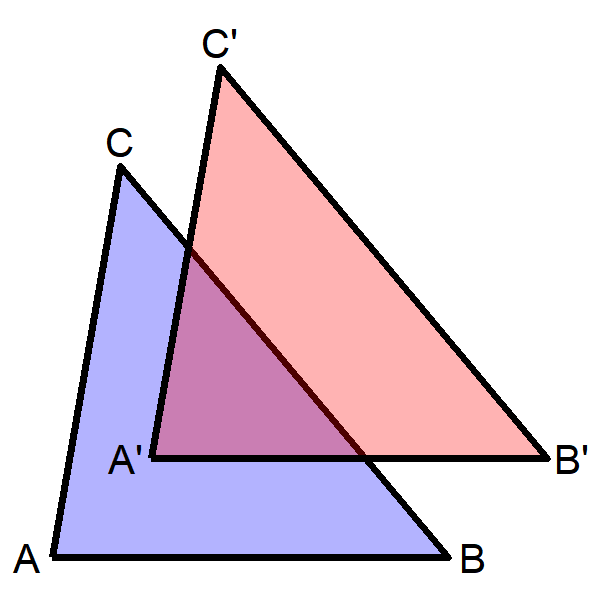

CorrectoIncorrecto

La afirmación es correcta.

**[Referencia: SEC_GT_IdentificarSuficienciaCongruencia]**

*Se tienen los triángulos ABC y A'B'C'. Si AB mide igual que A'B', CA mide igual que C'A' y el ángulo del vértice A mide igual que el del vértice A', entonces, por el criterio Lado-Ángulo-Lado (LAL) los triángulos ABC y A'B'C' son congruentes.*

¿Es correcto lo que se afirma?

CorrectoIncorrecto

La afirmación es correcta.

**[Referencia: SEC_GT_IdentificarSuficienciaCongruencia]**

Leer la siguiente afirmación. La figura que acompaña es una figura de análisis, es decir, es una figura alusiva.

*Se tienen los triángulos ABC y A'B'C'. Si los ángulos de los vértices C y B son de igual medida que los de los vértices C' y B', y el lado AB es de igual medida que el A'B', entonces, por el criterio Ángulo-Lado-Ángulo (ALA) los triángulos ABC y A'B'C' son congruentes.*

¿Es correcto lo que se afirma?

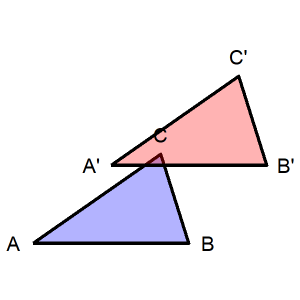

CorrectoIncorrecto

La afirmación es incorrecta.

**[Referencia: SEC_GT_IdentificarSuficienciaCongruencia]**

Leer la siguiente afirmación. La figura que acompaña es una figura de análisis, es decir, es una figura alusiva.

*Se tienen los triángulos ABC y A'B'C'. Si los ángulos de los vértices C y B son de igual medida que los de los vértices C' y B', y el lado AB es de igual medida que el A'B', entonces, por el criterio Ángulo-Lado-Ángulo (ALA) los triángulos ABC y A'B'C' son congruentes.*

¿Es correcto lo que se afirma?

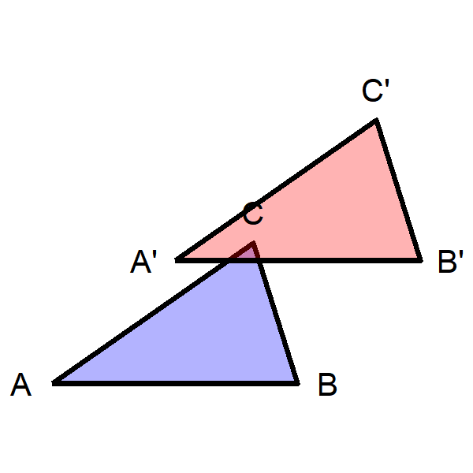

CorrectoIncorrecto

La afirmación es incorrecta.

**[Referencia: SEC_GT_IdentificarSuficienciaCongruencia]**

*Se tienen los triángulos ABC y A'B'C'. Si los ángulos de los vértices C y B son de igual medida que los de los vértices C' y B', y el lado AB es de igual medida que el A'B', entonces, por el criterio Ángulo-Lado-Ángulo (ALA) los triángulos ABC y A'B'C' son congruentes.*

¿Es correcto lo que se afirma?

CorrectoIncorrecto

La afirmación es incorrecta.

**[Referencia: SEC_GT_IdentificarSuficienciaCongruencia]**

Leer la siguiente afirmación. La figura que acompaña es una figura de análisis, es decir, es una figura alusiva.

*Se tienen los triángulos ABC y A'B'C'. Si los ángulos de los vértices C y B son de igual medida que los de los vértices C' y B', y el lado AB es de igual medida que el A'B', entonces, por el criterio Ángulo-Lado-Ángulo (ALA) los triángulos ABC y A'B'C' son congruentes.*

¿Es correcto lo que se afirma?

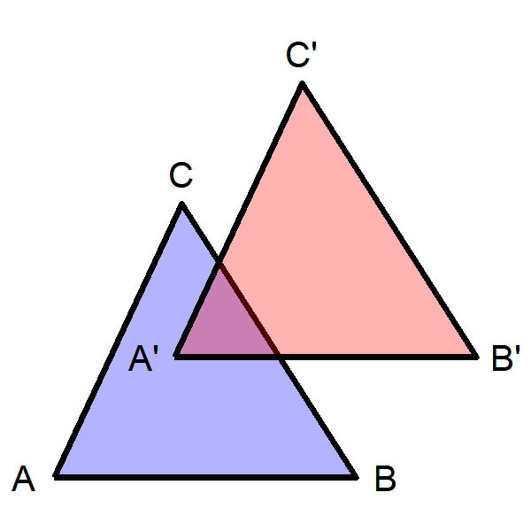

CorrectoIncorrecto

La afirmación es incorrecta.

**[Referencia: SEC_GT_IdentificarSuficienciaCongruencia]**

Leer la siguiente afirmación. La figura que acompaña es una figura de análisis, es decir, es una figura alusiva.

*Se tienen los triángulos ABC y A'B'C'. Si AB mide igual que A'B', CA mide igual que C'A' y el ángulo ACB mide igual que el A'C'B', entonces, por el criterio Lado-Ángulo-Lado (LAL) los triángulos ABC y A'B'C' son congruentes.*

¿Es correcto lo que se afirma?

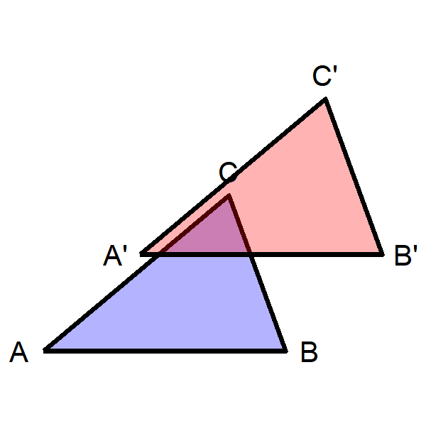

CorrectoIncorrecto

La afirmación es incorrecta.

**[Referencia: SEC_GT_IdentificarSuficienciaCongruencia]**

*Se tienen los triángulos ABC y A'B'C'. Si AB mide igual que A'B', CA mide igual que C'A' y el ángulo del vértice A mide igual que el del vértice A', entonces, por el criterio Lado-Ángulo-Lado (LAL) los triángulos ABC y A'B'C' son congruentes.*

¿Es correcto lo que se afirma?

CorrectoIncorrecto

La afirmación es correcta.

**[Referencia: SEC_GT_IdentificarSuficienciaCongruencia]**

*Se tienen los triángulos ABC y A'B'C'. Si los ángulos de los vértices C y B son de igual medida que los de los vértices C' y B', y el lado AB es de igual medida que el A'B', entonces, por el criterio Ángulo-Lado-Ángulo (ALA) los triángulos ABC y A'B'C' son congruentes.*

¿Es correcto lo que se afirma?

CorrectoIncorrecto

La afirmación es incorrecta.

**[Referencia: SEC_GT_IdentificarSuficienciaCongruencia]**

*Se tienen los triángulos ABC y A'B'C'. Si AB mide igual que A'B', CA mide igual que C'A' y el ángulo ACB mide igual que el A'C'B', entonces, por el criterio Lado-Ángulo-Lado (LAL) los triángulos ABC y A'B'C' son congruentes.*

¿Es correcto lo que se afirma?

CorrectoIncorrecto

La afirmación es incorrecta.

**[Referencia: SEC_GT_IdentificarSuficienciaCongruencia]**

Leer la siguiente afirmación. La figura que acompaña es una figura de análisis, es decir, es una figura alusiva.

*Se tienen los triángulos ABC y A'B'C'. Si los ángulos de los vértices C y B son de igual medida que los de los vértices C' y B', respectivamente, y el lado CB es de igual medida que el C'B', entonces, por el criterio Ángulo-Lado-Ángulo (ALA) los triángulos ABC y A'B'C' son congruentes.*

¿Es correcto lo que se afirma?

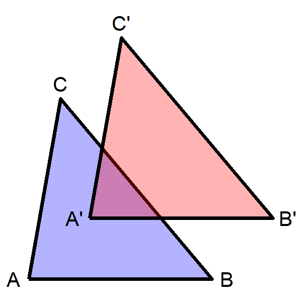

CorrectoIncorrecto

La afirmación es correcta.

**[Referencia: SEC_GT_IdentificarSuficienciaCongruencia]**

*Se tienen los triángulos ABC y A'B'C'. Si AB mide igual que A'B', CA mide igual que C'A' y el ángulo ACB mide igual que el A'C'B', entonces, por el criterio Lado-Ángulo-Lado (LAL) los triángulos ABC y A'B'C' son congruentes.*

¿Es correcto lo que se afirma?

CorrectoIncorrecto

La afirmación es incorrecta.

**[Referencia: SEC_GT_IdentificarSuficienciaCongruencia]**

Leer la siguiente afirmación. La figura que acompaña es una figura de análisis, es decir, es una figura alusiva.

*Se tienen los triángulos ABC y A'B'C'. Si los ángulos de los vértices C y B son de igual medida que los de los vértices C' y B', respectivamente, y el lado CB es de igual medida que el C'B', entonces, por el criterio Ángulo-Lado-Ángulo (ALA) los triángulos ABC y A'B'C' son congruentes.*

¿Es correcto lo que se afirma?

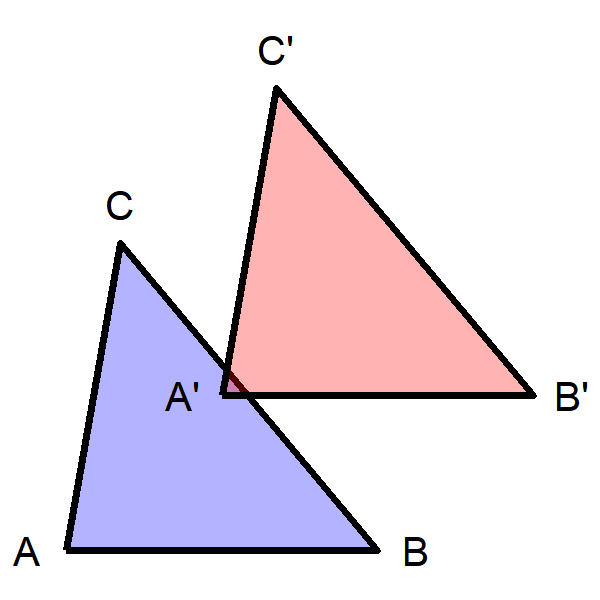

CorrectoIncorrecto

La afirmación es correcta.

**[Referencia: SEC_GT_IdentificarSuficienciaCongruencia]**

Leer la siguiente afirmación. La figura que acompaña es una figura de análisis, es decir, es una figura alusiva.

*Se tienen los triángulos ABC y A'B'C'. Si los ángulos de los vértices C y B son de igual medida que los de los vértices C' y B', respectivamente, y el lado CB es de igual medida que el C'B', entonces, por el criterio Ángulo-Lado-Ángulo (ALA) los triángulos ABC y A'B'C' son congruentes.*

¿Es correcto lo que se afirma?

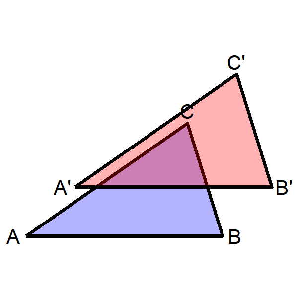

CorrectoIncorrecto

La afirmación es correcta.

**[Referencia: SEC_GT_IdentificarSuficienciaCongruencia]**

*Se tienen los triángulos ABC y A'B'C'. Si los ángulos de los vértices C y B son de igual medida que los de los vértices C' y B', y el lado AB es de igual medida que el A'B', entonces, por el criterio Ángulo-Lado-Ángulo (ALA) los triángulos ABC y A'B'C' son congruentes.*

¿Es correcto lo que se afirma?

CorrectoIncorrecto

La afirmación es incorrecta.

**[Referencia: SEC_GT_IdentificarSuficienciaCongruencia]**

Leer la siguiente afirmación. La figura que acompaña es una figura de análisis, es decir, es una figura alusiva.

*Se tienen los triángulos ABC y A'B'C'. Si los ángulos de los vértices C y B son de igual medida que los de los vértices C' y B', y el lado AB es de igual medida que el A'B', entonces, por el criterio Ángulo-Lado-Ángulo (ALA) los triángulos ABC y A'B'C' son congruentes.*

¿Es correcto lo que se afirma?

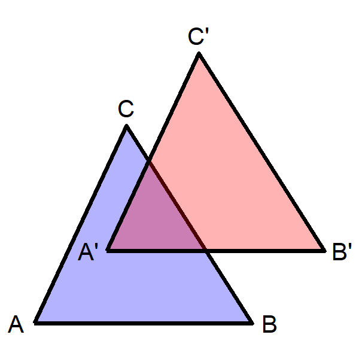

CorrectoIncorrecto

La afirmación es incorrecta.

**[Referencia: SEC_GT_IdentificarSuficienciaCongruencia]**

*Se tienen los triángulos ABC y A'B'C'. Si AB mide igual que A'B', CA mide igual que C'A' y el ángulo del vértice A mide igual que el del vértice A', entonces, por el criterio Lado-Ángulo-Lado (LAL) los triángulos ABC y A'B'C' son congruentes.*

¿Es correcto lo que se afirma?

CorrectoIncorrecto

La afirmación es correcta.

**[Referencia: SEC_GT_IdentificarSuficienciaCongruencia]**

Leer la siguiente afirmación. La figura que acompaña es una figura de análisis, es decir, es una figura alusiva.

*Se tienen los triángulos ABC y A'B'C'. Si AB mide igual que A'B', CA mide igual que C'A' y el ángulo ACB mide igual que el A'C'B', entonces, por el criterio Lado-Ángulo-Lado (LAL) los triángulos ABC y A'B'C' son congruentes.*

¿Es correcto lo que se afirma?

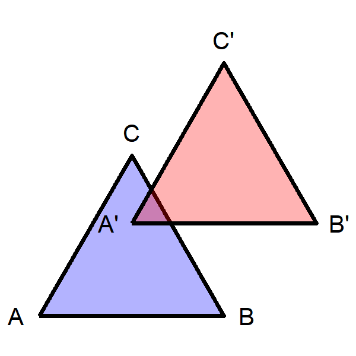

CorrectoIncorrecto

La afirmación es incorrecta.

**[Referencia: SEC_GT_IdentificarSuficienciaCongruencia]**

Leer la siguiente afirmación. La figura que acompaña es una figura de análisis, es decir, es una figura alusiva.

*Se tienen los triángulos ABC y A'B'C'. Si los ángulos de los vértices C y B son de igual medida que los de los vértices C' y B', y el lado AB es de igual medida que el A'B', entonces, por el criterio Ángulo-Lado-Ángulo (ALA) los triángulos ABC y A'B'C' son congruentes.*

¿Es correcto lo que se afirma?

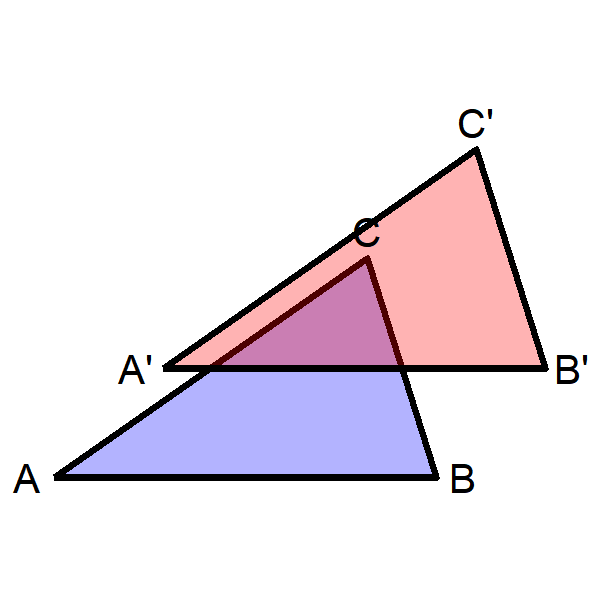

CorrectoIncorrecto

La afirmación es incorrecta.

**[Referencia: SEC_GT_IdentificarSuficienciaCongruencia]**

*Se tienen los triángulos ABC y A'B'C'. Si AB mide igual que A'B', CA mide igual que C'A' y el ángulo ACB mide igual que el A'C'B', entonces, por el criterio Lado-Ángulo-Lado (LAL) los triángulos ABC y A'B'C' son congruentes.*

¿Es correcto lo que se afirma?

CorrectoIncorrecto

La afirmación es incorrecta.

**[Referencia: SEC_GT_IdentificarSuficienciaCongruencia]**

Leer la siguiente afirmación. La figura que acompaña es una figura de análisis, es decir, es una figura alusiva.

*Se tienen los triángulos ABC y A'B'C'. Si los ángulos de los vértices C y B son de igual medida que los de los vértices C' y B', y el lado AB es de igual medida que el A'B', entonces, por el criterio Ángulo-Lado-Ángulo (ALA) los triángulos ABC y A'B'C' son congruentes.*

¿Es correcto lo que se afirma?

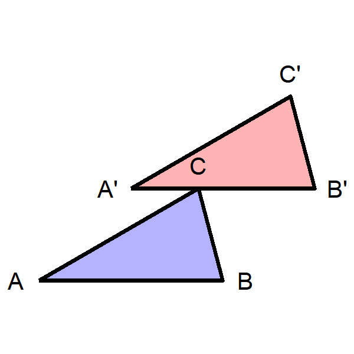

CorrectoIncorrecto

La afirmación es incorrecta.

**[Referencia: SEC_GT_IdentificarSuficienciaCongruencia]**

*Se tienen los triángulos ABC y A'B'C'. Si los ángulos de los vértices C y B son de igual medida que los de los vértices C' y B', y el lado AB es de igual medida que el A'B', entonces, por el criterio Ángulo-Lado-Ángulo (ALA) los triángulos ABC y A'B'C' son congruentes.*

¿Es correcto lo que se afirma?

CorrectoIncorrecto

La afirmación es incorrecta.

**[Referencia: SEC_GT_IdentificarSuficienciaCongruencia]**

*Se tienen los triángulos ABC y A'B'C'. Si los ángulos de los vértices C y B son de igual medida que los de los vértices C' y B', respectivamente, y el lado CB es de igual medida que el C'B', entonces, por el criterio Ángulo-Lado-Ángulo (ALA) los triángulos ABC y A'B'C' son congruentes.*

¿Es correcto lo que se afirma?

CorrectoIncorrecto

La afirmación es correcta.

**[Referencia: SEC_GT_IdentificarSuficienciaCongruencia]**

*Se tienen los triángulos ABC y A'B'C'. Si los ángulos de los vértices C y B son de igual medida que los de los vértices C' y B', respectivamente, y el lado CB es de igual medida que el C'B', entonces, por el criterio Ángulo-Lado-Ángulo (ALA) los triángulos ABC y A'B'C' son congruentes.*

¿Es correcto lo que se afirma?

CorrectoIncorrecto

La afirmación es correcta.

**[Referencia: SEC_GT_IdentificarSuficienciaCongruencia]**

*Se tienen los triángulos ABC y A'B'C'. Si los ángulos de los vértices C y B son de igual medida que los de los vértices C' y B', respectivamente, y el lado CB es de igual medida que el C'B', entonces, por el criterio Ángulo-Lado-Ángulo (ALA) los triángulos ABC y A'B'C' son congruentes.*

¿Es correcto lo que se afirma?

CorrectoIncorrecto

La afirmación es correcta.

**[Referencia: SEC_GT_IdentificarSuficienciaCongruencia]**

*Se tienen los triángulos ABC y A'B'C'. Si los ángulos de los vértices C y B son de igual medida que los de los vértices C' y B', respectivamente, y el lado CB es de igual medida que el C'B', entonces, por el criterio Ángulo-Lado-Ángulo (ALA) los triángulos ABC y A'B'C' son congruentes.*

¿Es correcto lo que se afirma?

CorrectoIncorrecto

La afirmación es correcta.

**[Referencia: SEC_GT_IdentificarSuficienciaCongruencia]**

Leer la siguiente afirmación. La figura que acompaña es una figura de análisis, es decir, es una figura alusiva.

*Se tienen los triángulos ABC y A'B'C'. Si los ángulos de los vértices C y B son de igual medida que los de los vértices C' y B', y el lado AB es de igual medida que el A'B', entonces, por el criterio Ángulo-Lado-Ángulo (ALA) los triángulos ABC y A'B'C' son congruentes.*

¿Es correcto lo que se afirma?

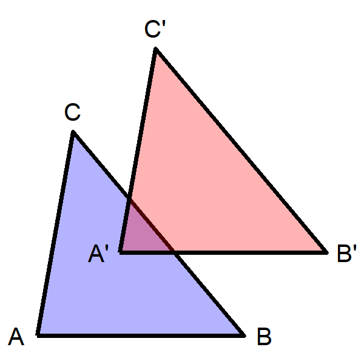

CorrectoIncorrecto

La afirmación es incorrecta.

**[Referencia: SEC_GT_IdentificarSuficienciaCongruencia]**

*Se tienen los triángulos ABC y A'B'C'. Si los ángulos de los vértices C y B son de igual medida que los de los vértices C' y B', respectivamente, y el lado CB es de igual medida que el C'B', entonces, por el criterio Ángulo-Lado-Ángulo (ALA) los triángulos ABC y A'B'C' son congruentes.*

¿Es correcto lo que se afirma?

CorrectoIncorrecto

La afirmación es correcta.

**[Referencia: SEC_GT_IdentificarSuficienciaCongruencia]**

*Se tienen los triángulos ABC y A'B'C'. Si AB mide igual que A'B', CA mide igual que C'A' y el ángulo ACB mide igual que el A'C'B', entonces, por el criterio Lado-Ángulo-Lado (LAL) los triángulos ABC y A'B'C' son congruentes.*

¿Es correcto lo que se afirma?

CorrectoIncorrecto

La afirmación es incorrecta.

**[Referencia: SEC_GT_IdentificarSuficienciaCongruencia]**

*Se tienen los triángulos ABC y A'B'C'. Si AB mide igual que A'B', CA mide igual que C'A' y el ángulo ACB mide igual que el A'C'B', entonces, por el criterio Lado-Ángulo-Lado (LAL) los triángulos ABC y A'B'C' son congruentes.*

¿Es correcto lo que se afirma?

CorrectoIncorrecto

La afirmación es incorrecta.

**[Referencia: SEC_GT_IdentificarSuficienciaCongruencia]**

Leer la siguiente afirmación. La figura que acompaña es una figura de análisis, es decir, es una figura alusiva.

*Se tienen los triángulos ABC y A'B'C'. Si AB mide igual que A'B', CA mide igual que C'A' y el ángulo ACB mide igual que el A'C'B', entonces, por el criterio Lado-Ángulo-Lado (LAL) los triángulos ABC y A'B'C' son congruentes.*

¿Es correcto lo que se afirma?

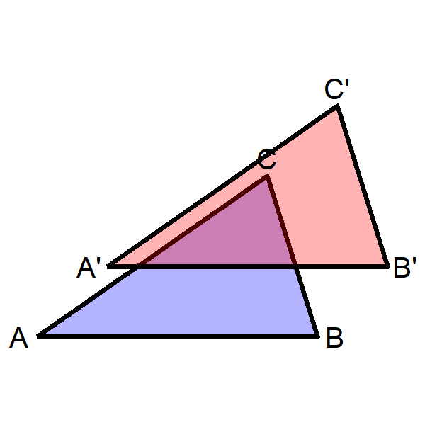

CorrectoIncorrecto

La afirmación es incorrecta.

**[Referencia: SEC_GT_IdentificarSuficienciaCongruencia]**

Leer la siguiente afirmación. La figura que acompaña es una figura de análisis, es decir, es una figura alusiva.

*Se tienen los triángulos ABC y A'B'C'. Si AB mide igual que A'B', CA mide igual que C'A' y el ángulo del vértice A mide igual que el del vértice A', entonces, por el criterio Lado-Ángulo-Lado (LAL) los triángulos ABC y A'B'C' son congruentes.*

¿Es correcto lo que se afirma?

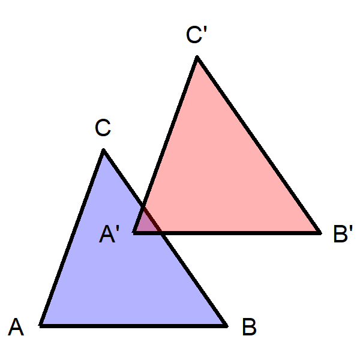

CorrectoIncorrecto

La afirmación es correcta.

**[Referencia: SEC_GT_IdentificarSuficienciaCongruencia]**

Leer la siguiente afirmación. La figura que acompaña es una figura de análisis, es decir, es una figura alusiva.

*Se tienen los triángulos ABC y A'B'C'. Si AB mide igual que A'B', CA mide igual que C'A' y el ángulo del vértice A mide igual que el del vértice A', entonces, por el criterio Lado-Ángulo-Lado (LAL) los triángulos ABC y A'B'C' son congruentes.*

¿Es correcto lo que se afirma?

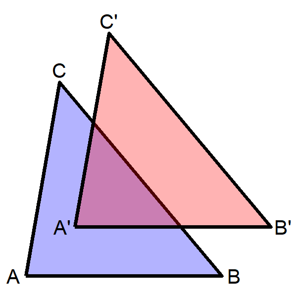

CorrectoIncorrecto

La afirmación es correcta.

**[Referencia: SEC_GT_IdentificarSuficienciaCongruencia]**

*Se tienen los triángulos ABC y A'B'C'. Si los ángulos de los vértices C y B son de igual medida que los de los vértices C' y B', respectivamente, y el lado CB es de igual medida que el C'B', entonces, por el criterio Ángulo-Lado-Ángulo (ALA) los triángulos ABC y A'B'C' son congruentes.*

¿Es correcto lo que se afirma?

CorrectoIncorrecto

La afirmación es correcta.

**[Referencia: SEC_GT_IdentificarSuficienciaCongruencia]**

*Se tienen los triángulos ABC y A'B'C'. Si AB mide igual que A'B', CA mide igual que C'A' y el ángulo del vértice A mide igual que el del vértice A', entonces, por el criterio Lado-Ángulo-Lado (LAL) los triángulos ABC y A'B'C' son congruentes.*

¿Es correcto lo que se afirma?

CorrectoIncorrecto

La afirmación es correcta.

**[Referencia: SEC_GT_IdentificarSuficienciaCongruencia]**

*Se tienen los triángulos ABC y A'B'C'. Si los ángulos de los vértices C y B son de igual medida que los de los vértices C' y B', y el lado AB es de igual medida que el A'B', entonces, por el criterio Ángulo-Lado-Ángulo (ALA) los triángulos ABC y A'B'C' son congruentes.*

¿Es correcto lo que se afirma?

CorrectoIncorrecto

La afirmación es incorrecta.

**[Referencia: SEC_GT_IdentificarSuficienciaCongruencia]**

Leer la siguiente afirmación. La figura que acompaña es una figura de análisis, es decir, es una figura alusiva.

*Se tienen los triángulos ABC y A'B'C'. Si AB mide igual que A'B', CA mide igual que C'A' y el ángulo ACB mide igual que el A'C'B', entonces, por el criterio Lado-Ángulo-Lado (LAL) los triángulos ABC y A'B'C' son congruentes.*

¿Es correcto lo que se afirma?

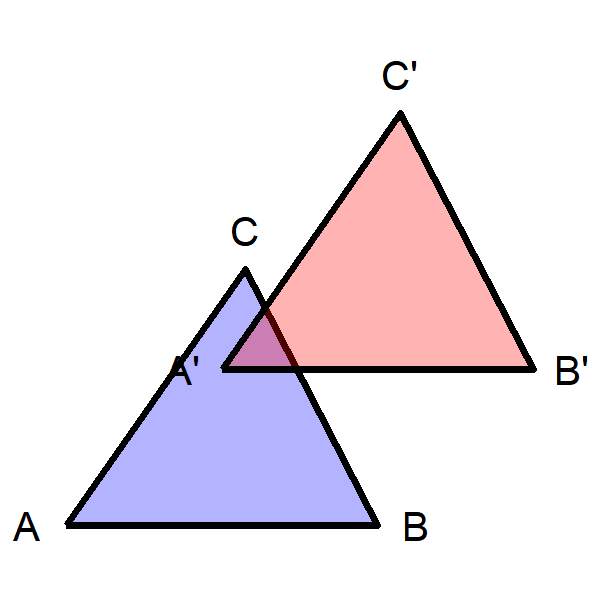

CorrectoIncorrecto

La afirmación es incorrecta.

**[Referencia: SEC_GT_IdentificarSuficienciaCongruencia]**

*Se tienen los triángulos ABC y A'B'C'. Si AB mide igual que A'B', CA mide igual que C'A' y el ángulo ACB mide igual que el A'C'B', entonces, por el criterio Lado-Ángulo-Lado (LAL) los triángulos ABC y A'B'C' son congruentes.*

¿Es correcto lo que se afirma?

CorrectoIncorrecto

La afirmación es incorrecta.

**[Referencia: SEC_GT_IdentificarSuficienciaCongruencia]**

*Se tienen los triángulos ABC y A'B'C'. Si AB mide igual que A'B', CA mide igual que C'A' y el ángulo del vértice A mide igual que el del vértice A', entonces, por el criterio Lado-Ángulo-Lado (LAL) los triángulos ABC y A'B'C' son congruentes.*

¿Es correcto lo que se afirma?

CorrectoIncorrecto

La afirmación es correcta.

**[Referencia: SEC_GT_IdentificarSuficienciaCongruencia]**

*Se tienen los triángulos ABC y A'B'C'. Si los ángulos de los vértices C y B son de igual medida que los de los vértices C' y B', y el lado AB es de igual medida que el A'B', entonces, por el criterio Ángulo-Lado-Ángulo (ALA) los triángulos ABC y A'B'C' son congruentes.*

¿Es correcto lo que se afirma?

CorrectoIncorrecto

La afirmación es incorrecta.

**[Referencia: SEC_GT_IdentificarSuficienciaCongruencia]**

Leer la siguiente afirmación. La figura que acompaña es una figura de análisis, es decir, es una figura alusiva.

*Se tienen los triángulos ABC y A'B'C'. Si los ángulos de los vértices C y B son de igual medida que los de los vértices C' y B', y el lado AB es de igual medida que el A'B', entonces, por el criterio Ángulo-Lado-Ángulo (ALA) los triángulos ABC y A'B'C' son congruentes.*